# 13_mann_kendall_sen_theil

Léa Bouchet

2024-06-06

# Objectif : Dynamique de population des poissons d’eau douce de Bretagne

Script : 13_mann_kendall_sen_theil

# Installation

## Chargement des packages, fonctions et des données

```r
## Chargement des packages ----
library(ggthemes)
library(tidyverse)
library(trend)
library(ggh4x)
```

```r
## Chargement des données
load(file = "../processed_data/calcul_indicateurs_regionaux.rda")
load(file = "../processed_data/analyse_indicateurs_regionaux_pour_mk_glm.rda")
```

```r
source(file = "../R/mk_st_by_group.R") # Fonction développée par Pascal Irz
source(file = "../R/mann_kendall_sen.R") # Fonction développée par Pascal Irz
source(file = "../R/mk_st_multi_periodes.R") #Fonction qui utilise des "" donc à corriger mais fait par Léa Bouchet
```

# Test de Mann-Kendall

## Introduction

Le test de tendance de Mann-Kendall est utilisé pour déterminer si une tendance existe ou non dans les données de séries chronologiques. Il s’agit d’un test non paramétrique, ce qui signifie qu’il n’y a pas d’hypothèse sous-jacente concernant la normalité des données.

Il s’agit d’un test d’hypothèses et les deux hypothèses sont les suivantes : 1. Ho (Accepté) : Il n’y a pas de tendance dans les données (valeur p>0,05). 2. Ha (Rejeté) : Une tendance est présente dans les données

## Application régionale

On souhaite le faire pour plusieurs périodes (création de la fonction *mk_st_multi_periodes*). Nous sélectionnons les périodes à étudier (qui sera une variable de la fonction) :

```r
reg_indicateur_reduit <- reg_indicateur_reduit %>%
  filter(indicateur %in% c("densite_surface",
                           "taux_occurrence",
                           "pourcentage_juveniles"),
         stade == "ind")
```

```r
periodes <- list(c(1990,2023),
                 c(2005, 2023),
                 c(2008, 2023),
                 c(2011, 2023),
                 c(2013, 2023))

#Nous exécutons la fonction *mk_st_multi_periodes* qui permet de calculer les différents test de Mann Kendall et pentes de Sen Theil pour les différentes périodes indiquées ci-avant.
```

```r
# reg_indicateur_lrr_tendances_lm <- reg_indicateur_lrr_tendances_lm %>%
#   rename(stade = stade.x)
```

```r
# Appeler la fonction pour calculer les résultats pour chaque période
reg_indicateur_lrr_tendances_mk_st <- mk_st_multi_periodes(df = reg_indicateur_reduit,
                                                              periods = periodes,
                                                              valeur = "valeur",
                                                              annee = "annee",
                                                              esp_code_alternatif = "esp_code_alternatif",
                                                              indicateur = "indicateur",
                                                              stade = "stade")

# Concaténer tous les résultats en un seul dataframe final
reg_indicateur_lrr_tendances_mk_st <- bind_rows(reg_indicateur_lrr_tendances_mk_st,
                                                .id = "periode")

# Filtrer les données selon les critères spécifiés
reg_indicateur_lrr_tendances_mk_st <- reg_indicateur_lrr_tendances_mk_st %>%
  filter(
    (esp_code_alternatif == "ANG" & periode == "1990-2023") |
    (esp_code_alternatif %in% c("CHE", "LPP") & periode == "2005-2023") |
    (esp_code_alternatif %in% c("BRO", "LOF") & periode == "2008-2023") |
    (esp_code_alternatif %in% c("VAR", "GAR", "VAI", "PER") & periode == "2011-2023") |
    (esp_code_alternatif %in% c("SAT", "GOU", "TRF", "CHA") & periode == "2013-2023")
  )
```

```r
# Créer le tableau synthétique avec gt
# tab_reg_indicateur_lrr_tendances_mk_st <- reg_indicateur_lrr_tendances_mk_st %>%
#   select(esp_code_alternatif,
#          periode,
#          indicateur,
#          trend,
#          sig) %>%
#   arrange(esp_code_alternatif,
#           indicateur) %>%   # Ordonner par espèce, indicateur et stade
#   gt() %>%
#   tab_header(
#     title = "Synthèse des tendances des indicateurs des populations de poissons d'eau douce de Bretagne"
#   ) %>%
#   cols_label(
#     esp_code_alternatif = "Code Espèce",
#     indicateur = "Indicateur",
#     trend = "Tendance Mann-Kendall / Sen Theil",
#     sig = "Significativité") %>%
#   tab_options(table.font.size = "small", data_row.padding = px(5))
#
# # Afficher le tableau
# tab_reg_indicateur_lrr_tendances_mk_st
```

## Application aux points de prélèvements

```r
library(tidyverse)
library(trend)
library(sf)
library(COGiter)
```

# Chargement des données :

```r
## Chargement de la palette de couleur
pal <- c("#007844", "#92D050", "#0087C1", "#A97B30","#FCEE21", "#00AEEF", "#1D1D1B", "#B9D9EB")
```

```r
## Chargement des données ----
load(file = "../processed_data/selection_pop_ope.rda")
load(file = "../processed_data/pre_traitements_donnees_env.rda")
load(file = "../processed_data/assemblage_tab_par_ope.rda")
load(file = "../processed_data/analyse_selection_especes.rda")
load(file = "../processed_data/selection_pop_ope_carte.rda")
```

```r
## Chargement des fonctions ----
source(file = "../R/mk_st_by_group.R")
source(file = "../R/calcul_taux_evolution.R")
source(file = "../R/mann_kendall_sen.R")
```

```r
mes_especes <- c("ANG","BRO", "CHA", "CHE","PER", "GAR", "GOU", "LOF", "LPP","SAT", "TRF", "VAI", "VAR")
```

# Distribution des espèces (significativité avec test mk_st par points de prélèvements)

```r
ope_densite <- ope_indicateur %>%
  filter(esp_code_alternatif %in% mes_especes,
         indicateur == "densite_surface",
         stade == "ind") # Nous avons 7475 observations (sans les absences)
```

On ajoute au dataframe les absences :

```r
ope_esp_densite <- ope_densite %>%
  select(-esp_code_alternatif, -valeur) %>%
  distinct() # df regroupant toutes mes opérations

# Création d'un dataframe avec toutes les combinaisons possibles d'années, indicateurs, stades et esp_code_alternatif
combinaisons_ope_densite <- expand.grid(esp_code_alternatif = unique(ope_densite$esp_code_alternatif),
                                    ope_id = unique(ope_densite$ope_id))

ope_densite_complet <- ope_esp_densite %>%
  left_join(y = combinaisons_ope_densite) %>%
  left_join(y = ope_densite) %>%
  mutate(valeur = ifelse(is.na(valeur), 0, valeur)) # Nous avons maintenant 13663 observations (avec les absences : 1051 opérations * 13 espèces)
```

## Pour la période LRR

```r
# On filtre les périodes d'étude de la Liste Rouge Régionale
ope_densite_periode_lrr <- ope_densite_complet %>%
  filter((esp_code_alternatif == "ANG" & annee >= 1990) |
      (esp_code_alternatif %in% c("CHE", "LPP") & annee >= 2005) |
      (esp_code_alternatif %in% c("BRO", "LOF", "VAR") & annee >= 2008) |
      (esp_code_alternatif %in% c("GAR", "VAI", "PER") & annee >= 2011) |
      (esp_code_alternatif %in% c("SAT", "GOU", "TRF", "CHA") & annee >= 2013))


ope_densite_periode_lrr_sans_abs <- ope_densite %>%
  filter((esp_code_alternatif == "ANG" & annee >= 1990) |
      (esp_code_alternatif %in% c("CHE", "LPP") & annee >= 2005) |
      (esp_code_alternatif %in% c("BRO", "LOF", "VAR") & annee >= 2008) |
      (esp_code_alternatif %in% c("GAR", "VAI", "PER") & annee >= 2011) |
      (esp_code_alternatif %in% c("SAT", "GOU", "TRF", "CHA") & annee >= 2013)) %>%
  select(esp_code_alternatif,
         pop_id) %>%
  distinct()
```

Calcul des tendances par points de prélèvements sur la période d’étude LRR :

```r
ope_densite_tendances_mk_st_lrr <- mk_st_by_group(ope_densite_periode_lrr,
                                                   valeur,
                                                   annee,
                                                   esp_code_alternatif,
                                                   indicateur,
                                                   stade,
                                                   pop_id) # Variable de groupage
```

# Pour la période globale (30 ans)

```r
# Calculate results
ope_densite_tendances_mk_st_globale <- mk_st_by_group(ope_densite_complet,
                                                      valeur,
                                                      annee,
                                                      esp_code_alternatif,
                                                      indicateur,
                                                      stade,
                                                      pop_id) # Variable de groupage
```

On renomme les variables en français /

```r
# Remplacer les valeurs
ope_densite_tendances_mk_st_globale <- ope_densite_tendances_mk_st_globale %>%
  mutate(trend = recode(trend, "Decrease" = "Diminution", "Increase" = "Augmentation", "No trend" = "Non significative")) %>%
  rename(Tendance = trend)

ope_densite_tendances_mk_st_lrr <- ope_densite_tendances_mk_st_lrr %>%
  mutate(trend = recode(trend, "Decrease" = "Diminution", "Increase" = "Augmentation", "No trend" = "Non significative")) %>%
  rename(Tendance = trend)
```

```r
# Pour ope_densite_tendances_mk_st_globale
ope_densite_tendances_mk_st_globale <- ope_densite_tendances_mk_st_globale %>%
  mutate(Tendance = recode(Tendance, "Decrease" = "Diminution", "Increase" = "Augmentation", "No trend" = "Non significative"),
         Tendance = if_else(is.nan(mk_pvalue), "Abs", Tendance)) %>%
  mutate(sig = case_when(
      mk_pvalue < 0.001 ~ "***",
      mk_pvalue < 0.01 ~ "**",
      mk_pvalue < 0.05 ~ "*",
      TRUE ~ ""
    ))
```

```r
# Pour ope_densite_tendances_mk_st_lrr
ope_densite_tendances_mk_st_lrr <- ope_densite_tendances_mk_st_lrr %>%
  mutate(Tendance = recode(Tendance, "Decrease" = "Diminution", "Increase" = "Augmentation", "No trend" = "Non significative"),
         Tendance = if_else(is.nan(mk_pvalue), "Abs", Tendance)) %>%
  mutate(sig = case_when(
      mk_pvalue < 0.001 ~ "***",
      mk_pvalue < 0.01 ~ "**",
      mk_pvalue < 0.05 ~ "*",
      TRUE ~ ""
    ))
```

## Représentation graphique

Préparation des données géographiques (carte de fond)

```r
mes_depts <- departements_metro_geo %>%
  filter(DEP %in% c("22", "29", "35", "56", "53", "44", "50", "49")) %>%
  st_transform(crs = 4326) %>%
  st_crop(
    xmin = -5,
    xmax = -0.9,
    ymin = 47.4,
    ymax = 49
  )
```

## Pour la période LRR :

On ne veut faire que apparaitre les points où il y a déjà eu de la présence :

```r
ope_densite_code_periode_lrr <- ope_densite_periode_lrr %>%
  select(esp_code_alternatif,
         pop_id) %>%
  distinct()

ope_densite_code_complet_periode_lrr <- ope_densite_periode_lrr_sans_abs %>%
  left_join(ope_densite_tendances_mk_st_lrr)
```

```r
mes_esp_rapport <- c("ANG", "GAR", "SAT", "TRF")
mes_sta_supp <- c("42207", "44190", "47049")
```

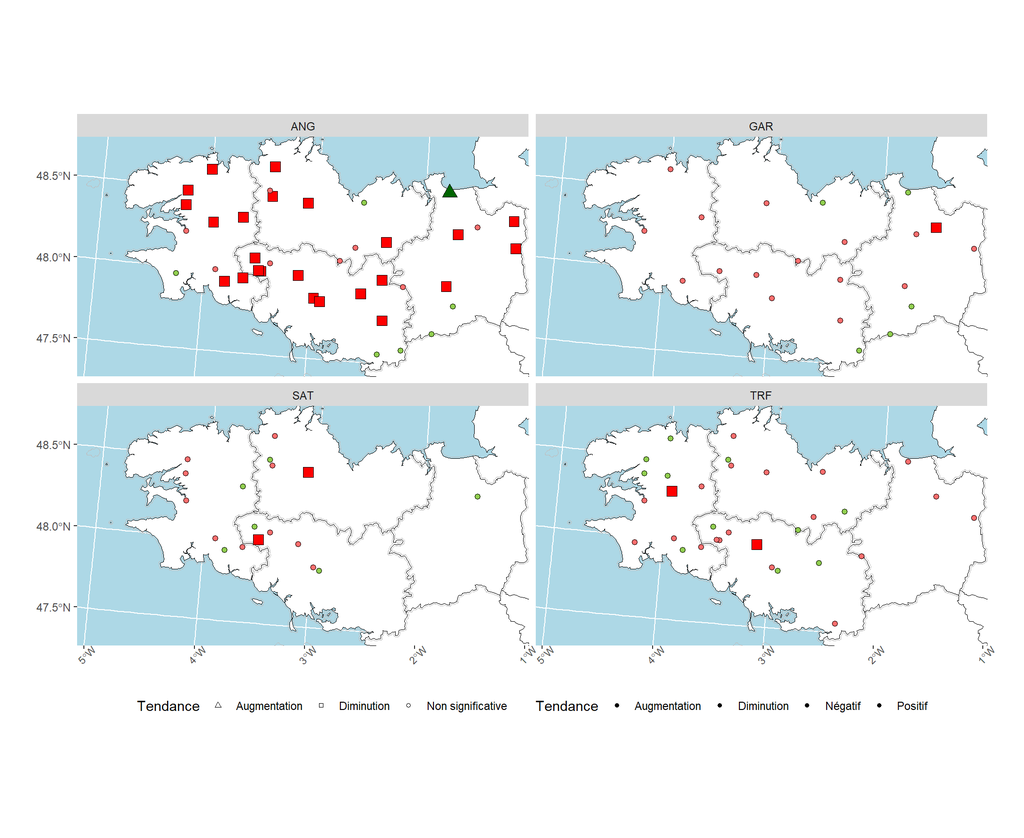

```r
carte_tendance_lrr <- ggplot(sta_id_ope_selection %>%
                               left_join(ope_densite_code_complet_periode_lrr, by = "pop_id") %>%
                               filter(esp_code_alternatif %in% mes_esp_rapport,
                                      !pop_id %in% mes_sta_supp) %>%
                               filter(!is.na(Tendance))) +
  geom_sf(data = mes_depts, fill = "white", color = "black") +
  geom_sf(data = buffer, fill = NA, color = "grey") +
  geom_sf(aes(shape = Tendance,
              fill = ifelse(Tendance == "Non significative",
                            ifelse(sens_slope > 0, "Positif", "Négatif"), Tendance),
              size = factor(ifelse(Tendance == "Non significative", 1, 2))),
          stroke = 0.2) +
  scale_fill_manual(
    name = "Tendance",
    values = c(
      "Diminution" = "red",
      "Augmentation" = "darkgreen",
      "Non significative" = "gray",
      "Positif" = "#92D050",
      "Négatif" = "#FF6F6F"
    )
  ) +
  scale_shape_manual(
    name = "Tendance",
    values = c(
      "Diminution" = 22, # carré plein
      "Augmentation" = 24, # triangle plein
      "Non significative" = 21 # cercle plein
    )
  ) +
  scale_size_manual(
    values = c("1" = 2, "2" = 4),
    guide = 'none'
  ) +
  facet_wrap(~ esp_code_alternatif) +
  theme(
    panel.background = element_rect(fill = "lightblue"),
    legend.position = "bottom",
    legend.key = element_rect(fill = NA),
    axis.text.x = element_text(size = 8, angle = 45, hjust = 0.5),
    plot.margin = unit(c(1, 1, 1, 1), "cm"))
#  ggtitle("Tendances temporelles des densités par espèces à l'échelle des points de prélèvement - période LRR ")

carte_tendance_lrr <- carte_tendance_lrr + coord_sf(xlim = c(-5, -1.2), ylim = c(47.45, 48.8), default_crs = 4326)

carte_tendance_lrr
```

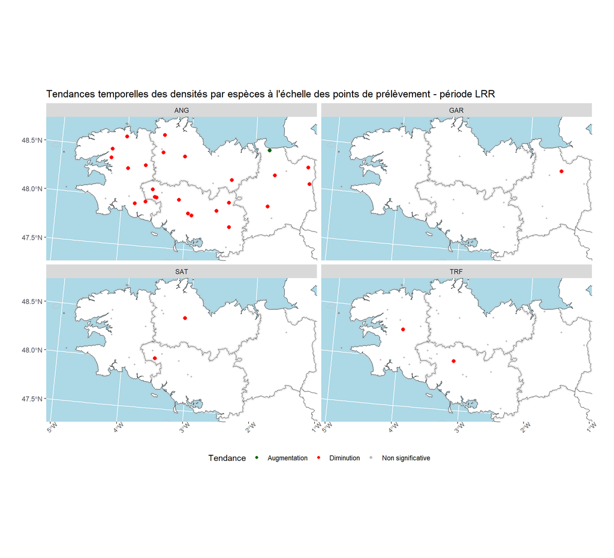

```r
# Combine data and plot with facet_wrap
carte_tendance_lrr <- ggplot(sta_id_ope_selection %>%
                            left_join(ope_densite_code_complet_periode_lrr,
                                      by = "pop_id") %>%
                            filter(
                              esp_code_alternatif %in% mes_esp_rapport,
                                   !pop_id %in% mes_sta_supp)%>%
                            filter(!is.na(Tendance))) +
  geom_sf(data = mes_depts, fill = "white", color = "black") +
  geom_sf(data = buffer, fill = NA, color = "grey") +
  geom_sf(aes(col = Tendance,
              size = (Tendance != "Non significative"))) +
  scale_color_manual(name = "Tendance",
                     values = c("Diminution" = "red",
                                "Augmentation" = "darkgreen",
                                "Non significative" = "gray")) +
  scale_size_manual(values = c(0.8, 2),
                    guide = 'none') +
  facet_wrap(~ esp_code_alternatif) +
  theme(panel.background = element_rect(fill = "lightblue"),
        legend.position = "bottom",
        legend.key = element_rect(fill = NA),
        axis.text.x = element_text(size = 8, angle = 45, hjust = 0.5), # Ajustements ici
        plot.margin = unit(c(1, 1, 1, 1), "cm")) +
  ggtitle("Tendances temporelles des densités par espèces à l'échelle des points de prélèvement - période LRR ")

carte_tendance_lrr <- carte_tendance_lrr + coord_sf(xlim = c(-5, -1.2), ylim = c(47.45, 48.8), default_crs = 4326)

carte_tendance_lrr
```

```r
ggsave(filename = "../assets/carte_tendances_sta_lrr.png",
       plot = carte_tendance_lrr, width = 10, height = 8, dpi = 300) # Enregistrer l'image
```

## Pour la période globale

On ne veut faire que apparaitre les points où il y a déjà eu de la présence :

```r
ope_densite_code <- ope_densite %>%
  select(esp_code_alternatif,
         pop_id) %>%
  distinct()

ope_densite_code_complet <- ope_densite_code %>%
  left_join(ope_densite_tendances_mk_st_globale)
```

Représentation de la carte globale

```r
# Combine data and plot with facet_wrap
carte_sta_facet_globale <- ggplot(sta_id_ope_selection %>%
                            left_join(ope_densite_code_complet, by = "pop_id") %>%
                            filter(
                              esp_code_alternatif %in% mes_esp_rapport,
                                    !pop_id %in% mes_sta_supp)) +
  geom_sf(data = mes_depts, fill = "white", color = "black") +
  geom_sf(data = buffer, fill = NA, color = "grey") +
  geom_sf(aes(col = Tendance,
              size = (Tendance != "Non significative"))) +
  scale_color_manual(name = "Tendance",
                     values = c("Diminution" = "red",
                                "Augmentation" = "darkgreen",
                                "Non significative" = "gray")) +
  scale_size_manual(values = c(0.8, 2),
                    guide = 'none') +
  facet_wrap(~ esp_code_alternatif) +
  theme(panel.background = element_rect(fill = "lightblue"),
        legend.position = "bottom",
        legend.key = element_rect(fill = NA),
        axis.text.x = element_text(size = 8, angle = 45, hjust = 0.5), # Ajustements ici
        plot.margin = unit(c(1, 1, 1, 1), "cm")) +
   ggtitle("Tendances temporelles des densités par espèce à l'échelle des points de prélèvement - période globale (30 ans)")

carte_sta_facet_globale <- carte_sta_facet_globale + coord_sf(xlim = c(-5, -1.2), ylim = c(47.45, 48.8), default_crs = 4326)
```

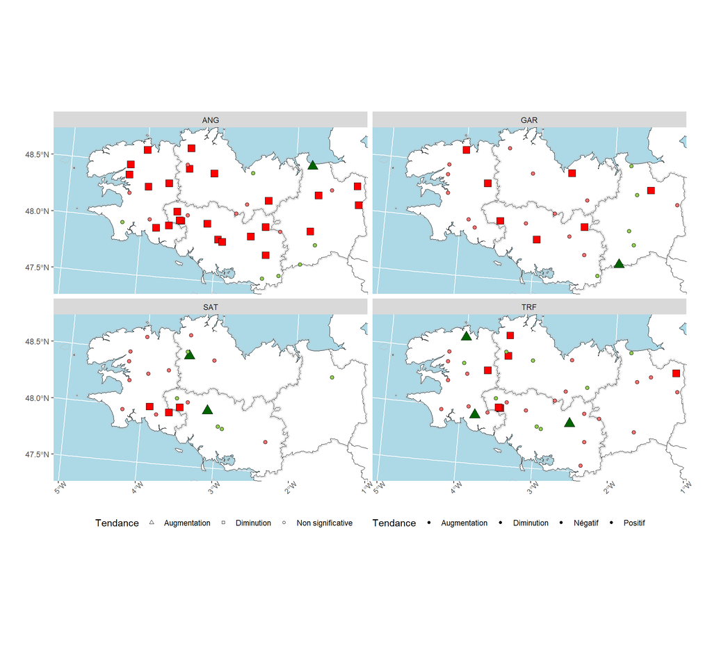

```r
carte_sta_facet_globale <- ggplot(sta_id_ope_selection %>%
                            left_join(ope_densite_code_complet, by = "pop_id") %>%
                            filter(
                              esp_code_alternatif %in% mes_esp_rapport,
                                    !pop_id %in% mes_sta_supp)) +
  geom_sf(data = mes_depts, fill = "white", color = "black") +
  geom_sf(data = buffer, fill = NA, color = "grey") +
  geom_sf(aes(shape = Tendance,
              fill = ifelse(Tendance == "Non significative",
                            ifelse(sens_slope > 0, "Positif", "Négatif"), Tendance),
              size = factor(ifelse(Tendance == "Non significative", 1, 2))),
          stroke = 0.2) +
  scale_fill_manual(
    name = "Tendance",
    values = c(
      "Diminution" = "red",
      "Augmentation" = "darkgreen",
      "Non significative" = "gray",
      "Positif" = "#92D050",
      "Négatif" = "#FF6F6F"
    )
  ) +
  scale_shape_manual(
    name = "Tendance",
    values = c(
      "Diminution" = 22, # carré plein
      "Augmentation" = 24, # triangle plein
      "Non significative" = 21 # cercle plein
    )
  ) +
  scale_size_manual(
    values = c("1" = 2, "2" = 4),
    guide = 'none'
  ) +
  facet_wrap(~ esp_code_alternatif) +
  theme(
    panel.background = element_rect(fill = "lightblue"),
    legend.position = "bottom",
    legend.key = element_rect(fill = NA),
    axis.text.x = element_text(size = 8, angle = 45, hjust = 0.5),
    plot.margin = unit(c(1, 1, 1, 1), "cm"))
#  ggtitle("Tendances temporelles des densités par espèces à l'échelle des points de prélèvement - période LRR ")

carte_sta_facet_globale <- carte_sta_facet_globale + coord_sf(xlim = c(-5, -1.2), ylim = c(47.45, 48.8), default_crs = 4326)

carte_sta_facet_globale
```

```r
# ggsave(filename = "../assets/carte_tendances_sta_globale.png",
#        plot = carte_sta_facet_globale, width = 10, height = 8, dpi = 300) # Enregistrer l'image
```

# Sauvegarde

```r
# save(reg_indicateur_lrr_tendances_mk_st,
#      reg_indicateur_lrr_tendances_lm,
#      tab_reg_indicateur_lrr_tendances_mk_st,
#      tab_reg_indicateur_lrr_tendances_lm,
#      file = "../processed_data/lm_mann_kendall_tendances.rda")
```